# Session 8 - Refining plots

Fabian Gülzau

14 Dezember 2017

# Programm

1. Recap
2. Verwendung von Farben und Farbpaletten
3. Beispieldaten: Stammdaten der MdB
4. Altersverteilung der MdB
5. Aufgabe: Verfeinern von existierenden Grafiken (Gruppenarbeit)

# Recap I

Wir haben bisher…

1. Das Paket `dplyr` kennengelernt
- `mutate`
- `filter`
- `summarize`
- `select`
- … (`%>%`, `group_by`)
2. Die Grundlagen von `ggplot2` betrachtet
- grammar of graphics
- layer
3. Erste “feinere” Optionen von `ggplot2` verwendet

# Recap: Themes

In der letzten Sitzung haben wir verschiedene “themes” betrachtet, welche Grafiken hinzugefügt werden können, um diese schnell zu verändern:

Der ‘simple’ Plot:

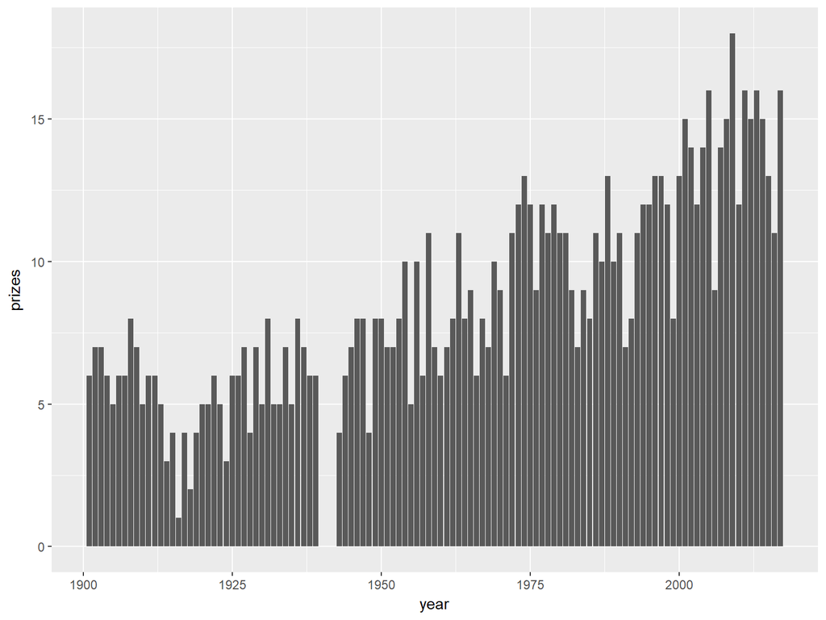

```r
ggplot(data = nobel.year, mapping = aes(x = year, y = prizes)) +
  geom_bar(stat = "identity")
```

ggplot2-Themes:

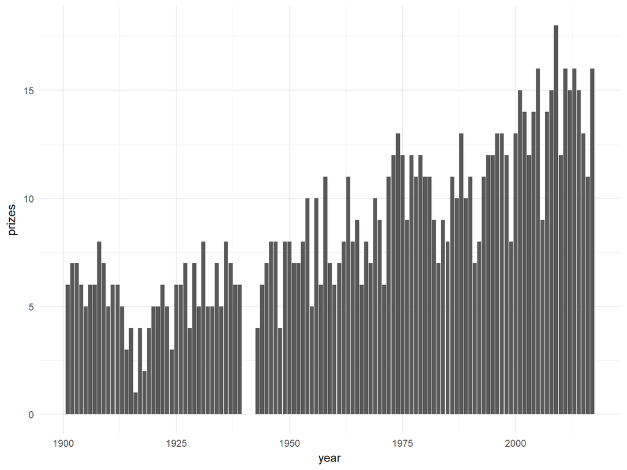

```r
ggplot(data = nobel.year, mapping = aes(x = year, y = prizes)) +
  geom_bar(stat = "identity") +
  theme_minimal()
```

ggthemes:

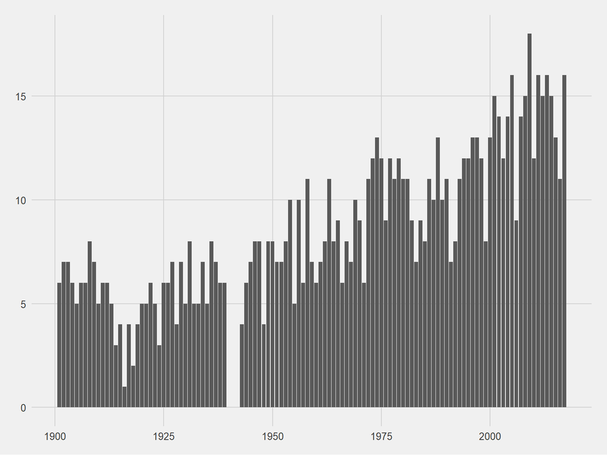

```r
ggplot(data = nobel.year, mapping = aes(x = year, y = prizes)) +
  geom_bar(stat = "identity") +
  theme_fivethirtyeight()
```

Zudem lassen sich über die Funktion `theme` eine ganze Bandbreite an Optionen steuern: `?theme`.

# Recap: Labs

Wir hab uns zudem mit einigen Optionen, die über `labs` verfügbar sind, beschäftigt:

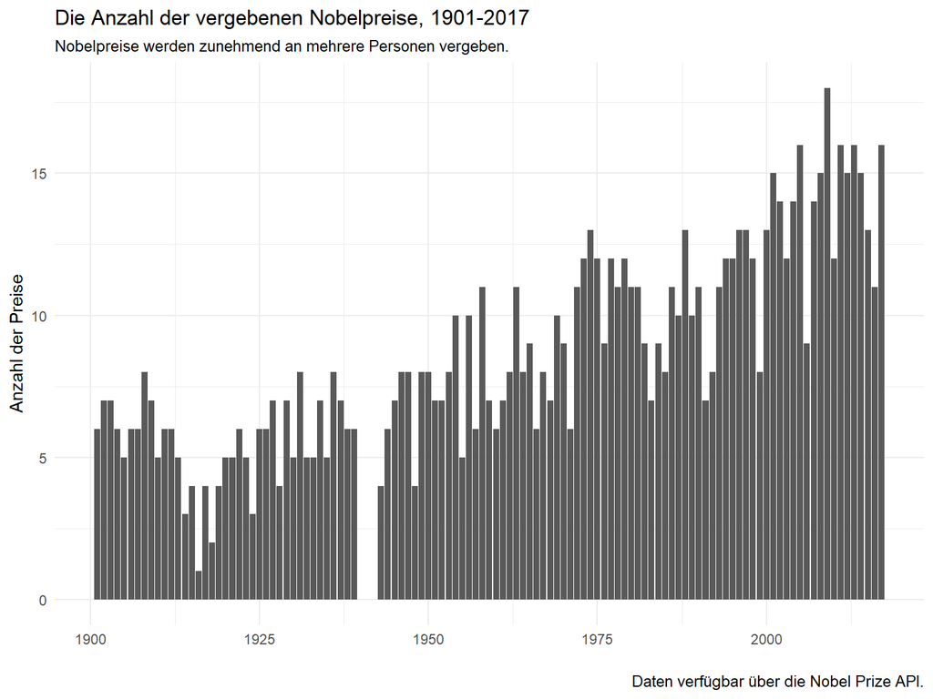

```r
prizes <- ggplot(data = nobel.year, mapping = aes(x = year, y = prizes)) +
  geom_bar(stat = "identity") +
  theme_minimal() +
  labs(title = "Die Anzahl der vergebenen Nobelpreise, 1901-2017",
       subtitle = "Nobelpreise werden zunehmend an mehrere Personen vergeben.",
       caption = "Daten verfügbar über die Nobel Prize API.",
       x = "",
       y = "Anzahl der Preise")

prizes
```

# Recap: `annotate`

Zuletzt haben wir bestimmte Beobachtungen hervorgehoben und hierbei `annotate` verwendet:

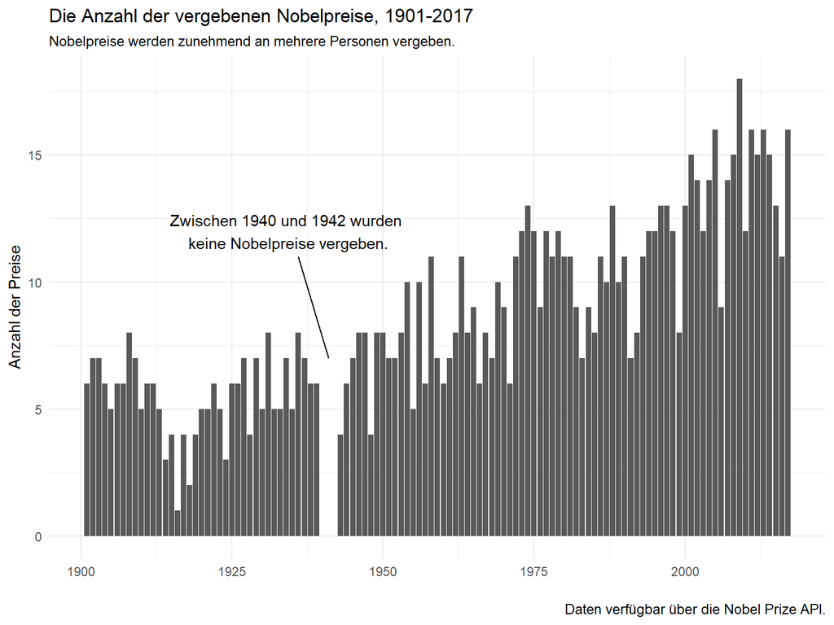

```r
prizes <- prizes +
  annotate(geom = "segment", x = 1936, xend = 1941, y = 11, yend = 7) +
  annotate(geom = "text", x = 1934, y = 12,
           label = "Zwischen 1940 und 1942 wurden\n keine Nobelpreise vergeben.")

prizes
```

# Farben und Farbpaletten

Heute werden wir einige weitere Optionen von `ggplot2` erproben. Hierzu gehört insbesondere der Einsatz von Farben.

Um Farben und Farbpaletten auszuwählen, lässt sich das Paket `RColorBrewer` verwenden.

```r
install.packages("RColorBrewer")
library("RColorBrewer")
```

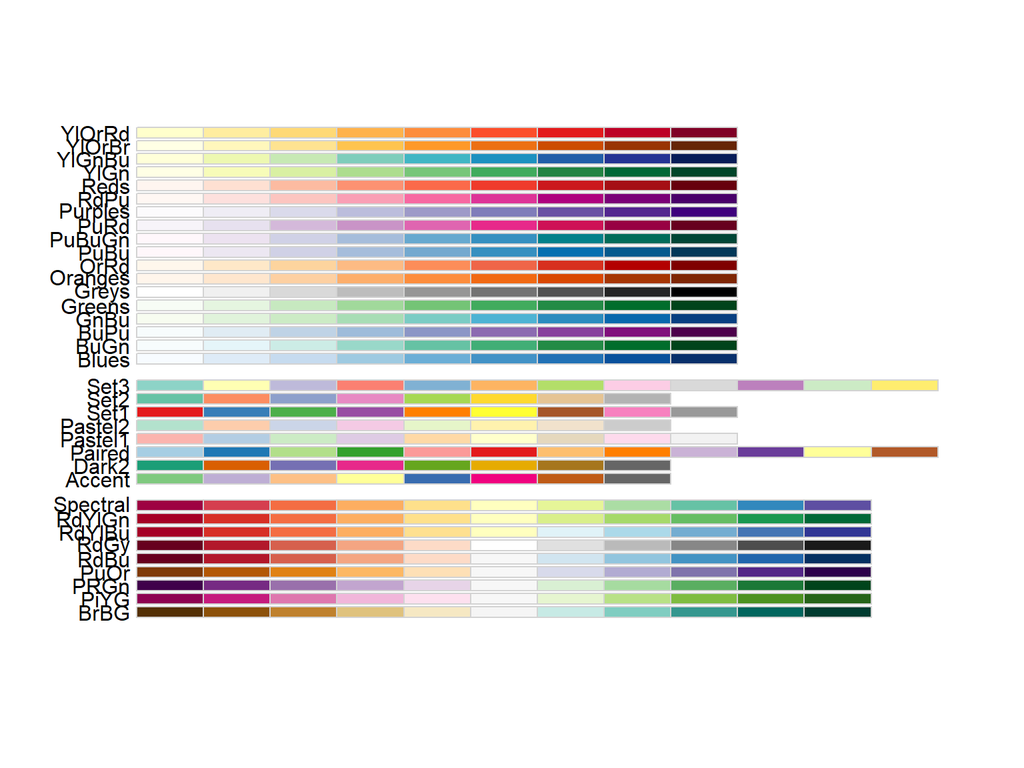

```r
display.brewer.all()
```

Auch die Internetseite http://colorbrewer2.org ist hilfreich.

# Daten: Stammdaten der MdB I

Viele [Informationen](https://www.bundestag.de/service/opendata) zu Mitgliedern des Bundestages sind online verfügbar:

- [XML-Format](https://www.bundestag.de/service/opendata)
- Daten ab 1949
- Parlamentsdebatten sind auch als Protokolle verfügbar

# Daten: Stammdaten der MdB II

Struktur der Originaldaten:

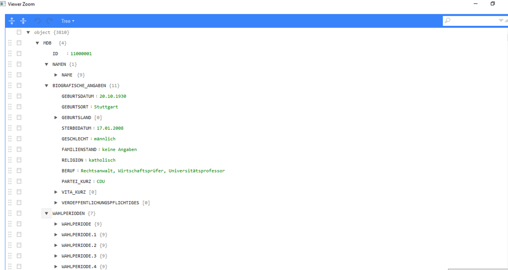

# Daten: Stammdaten der MdB III

Ich habe die Daten bereits in einen `data.frame` umgewandelt (WP 18) und einige Variable hinzugefügt. Der Datensatz enthält nun folgende Variablen:

```r
glimpse(mdb18.df)
```

```
## Observations: 620
## Variables: 11
## $ ID            <chr> "11000240", "11000305", "11000365", "11000489", ...
## $ firstname     <chr> "Klaus", "Edelgard", "Jörg-Diether", "Gernot", "...
## $ surname       <chr> "Brähmig", "Bulmahn", "Dehm-Desoi", "Erler", "Fe...
## $ birth         <int> 1957, 1951, 1950, 1944, 1958, 1952, 1964, 1948, ...
## $ birthplace    <chr> "Königstein / Krs. Pirna", "Petershagen / Westfa...
## $ gender        <chr> "männlich", "weiblich", "männlich", "männlich", ...
## $ party         <chr> "CDU", "SPD", "DIE LINKE.", "SPD", "SPD", "CDU",...
## $ election.last <chr> "18", "18", "18", "18", "18", "18", "18", "18", ...
## $ election.from <chr> "22.10.2013", "22.10.2013", "22.10.2013", "22.10...
## $ formation     <int> 2013, 2013, 2013, 2013, 2013, 2013, 2013, 2013, ...
## $ age           <int> 56, 62, 63, 69, 55, 61, 49, 65, 63, 63, 57, 62, ...
```

# Shading, Farben und geom_text

Es gibt verschiedene Möglichkeiten einzelne Beobachtungen hervorzuheben:

- shading (Cairo 2013 “The Functional Art”)
- Farben ([NASA 2013](https://earthobservatory.nasa.gov/blogs/elegantfigures/2013/08/05/subtleties-of-color-part-1-of-6/))
- Text

# Ein Beispiel : Altersstruktur WP18

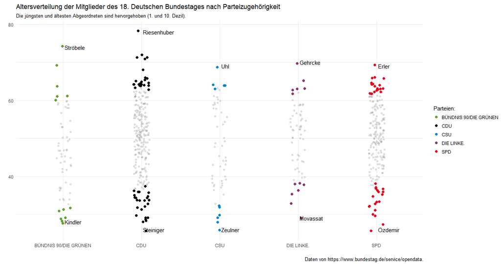

# Altersstruktur WP18 I

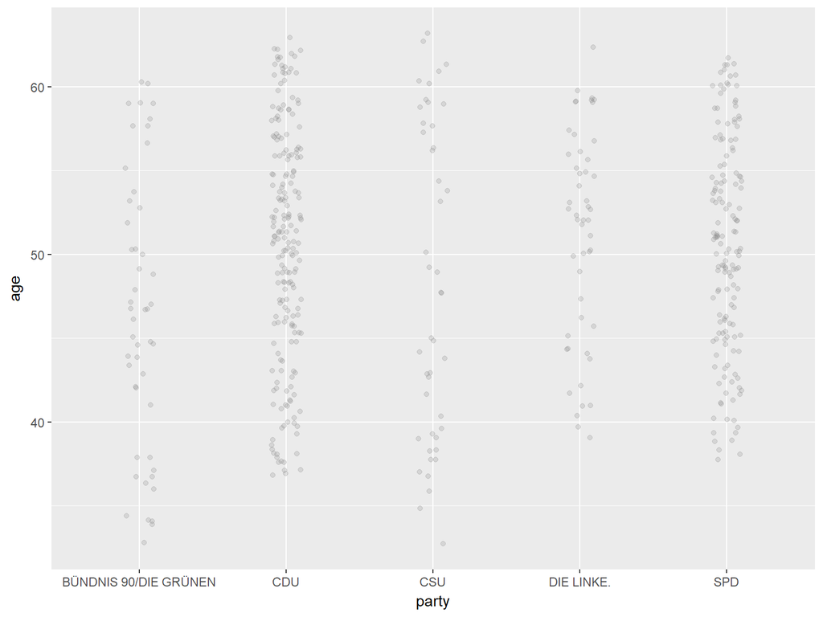

```r
## Data preparation:
# Rough deciles
age.df <- mdb18.df %>%
  group_by(party) %>%
  mutate(rank = ntile(x = age, n = 10))

# Deciles 2-8
mid.age <- age.df %>%
  filter(rank > 1 & rank < 10)

# Decile 1 and 10
dev.age <- age.df %>%
  filter(rank == 1 | rank == 10)

## Plot:
plot.age <- ggplot(data = mid.age, aes(x = party, y = age)) +
  geom_jitter(stat = "identity", width = 0.1, color = "gray50", alpha = 0.2)

plot.age
```

# Altersstruktur WP18 II

Die Verwendung von [Farben](http://www.stat.columbia.edu/~tzheng/files/Rcolor.pdf):

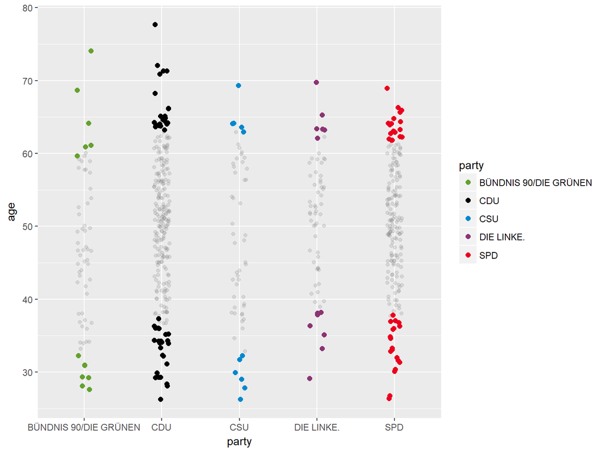

```r
# Farben
plot.age <- plot.age +
  geom_jitter(data = dev.age, mapping = aes(x = party, y = age, color = party), stat = "identity", width = 0.1, size = 2) +
  scale_color_manual(values = c("#64A12D", "#000000", "#0088CE", "#8C3473", "#EB001F"))

plot.age
```

# Altersstruktur WP18 III

`labs` und `theme`:

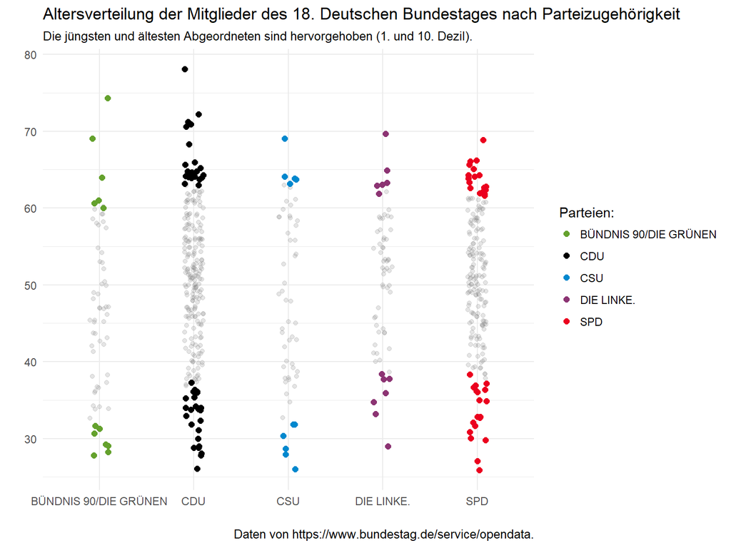

```r
plot.age <- plot.age +
  labs(title = "Altersverteilung der Mitglieder des 18. Deutschen Bundestages nach Parteizugehörigkeit",
       subtitle = "Die jüngsten und ältesten Abgeordneten sind hervorgehoben (1. und 10. Dezil).",
       caption = "Daten von https://www.bundestag.de/service/opendata.",
       color = " Parteien: ",
       x = "",
       y = "") +
  theme_minimal()

plot.age
```

# Altersstruktur WP18 IV

`geom_text`:

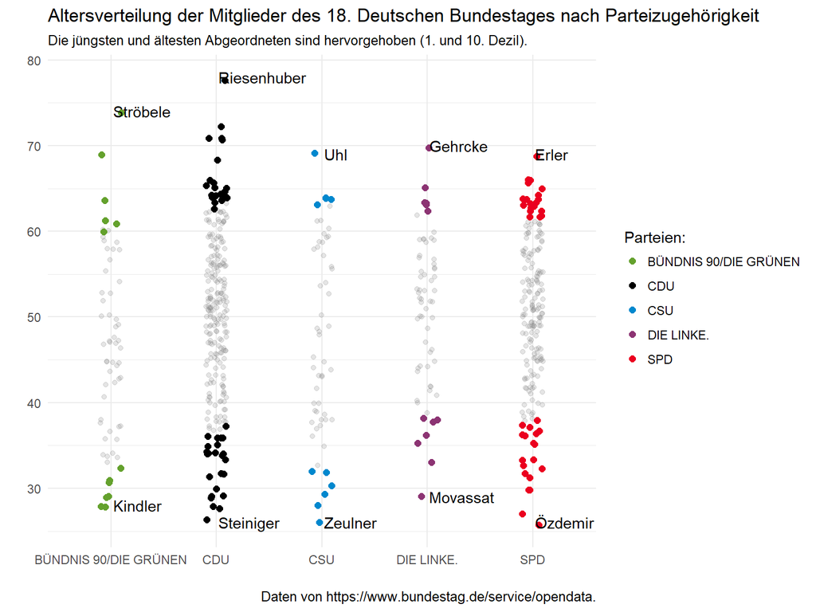

```r
# Identify youngest and oldest MdB by party
abs.dev.age <- dev.age %>%
  group_by(party) %>%
  summarize(minAge = age[which.min(age)],
            maxAge = age[which.max(age)],
            name.min = surname[which.min(age)],
            name.max = surname[which.max(age)])

age.abs <- dev.age %>%
  mutate(minmax.age = surname %in% c(abs.dev.age$name.max, abs.dev.age$name.min) == 1) %>%
  filter(minmax.age == TRUE)

# Plot:
plot.age <- plot.age +
  geom_text(data = age.abs, mapping = aes(label = surname),  hjust = 0, nudge_x = 0.02)

plot.age
```

# RColorBrewer und ggplot2

Oben haben wir mit `scale_color_manual` die Farben selbst gewählt. Es lassen sich aber auch vorab definierte Farben verwenden. Diese lassen sich über ihren Namen abrufen.

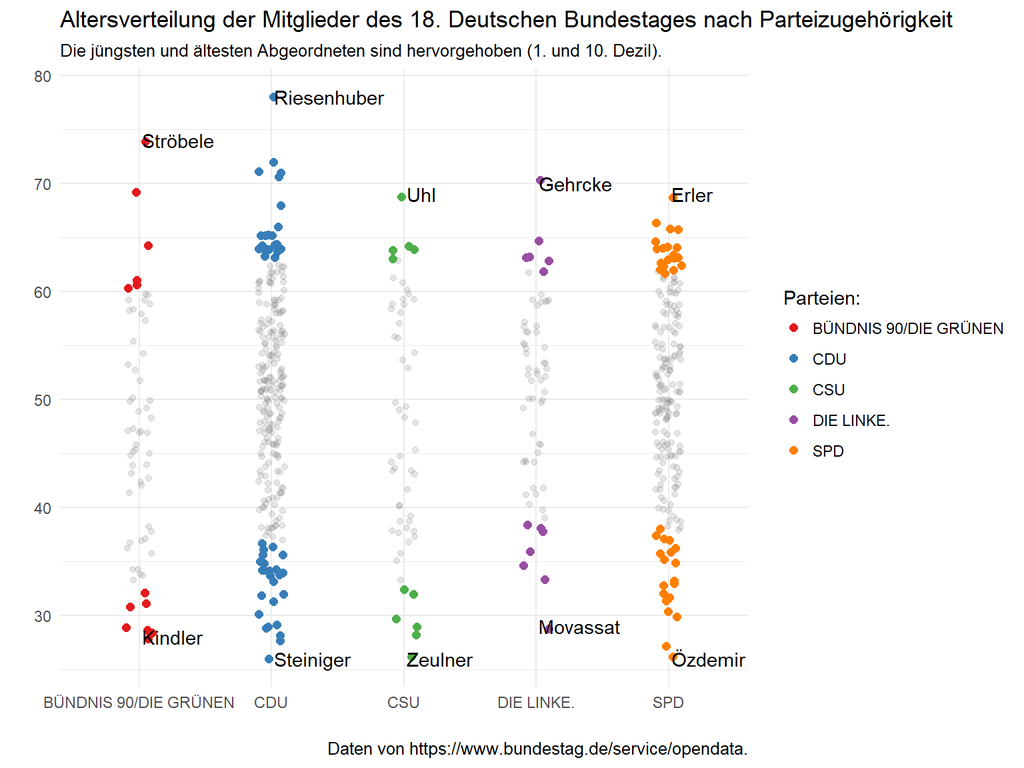

```r
plot.age +
  scale_color_brewer(palette = "Set1")
```